# Microbial Competition & Tree Adaptations

Replicating and Extending Jiang et al. (Nature, 2024)

Author

ok bro

Published

December 11, 2025

## 1. Introduction & Objectives

Elevated eCO2 is expected to increase forest growth. However, Jiang et al. (2024) showed that in P-limited soils, growth stagnates because microbes “pre-empt” (steal) the phosphorus.

**Our Objective:**  
Is the forest truly passive? We replicate the “stagnation” finding but extend the analysis to test for **Functional Plasticity** - the ability of trees to adapt their physiology (efficiency and rooting) even if biomass doesn’t appear to change.

## 2. Replication Phase: The Problem

We first confirm the paper’s mechanism using 2013-2016 data.

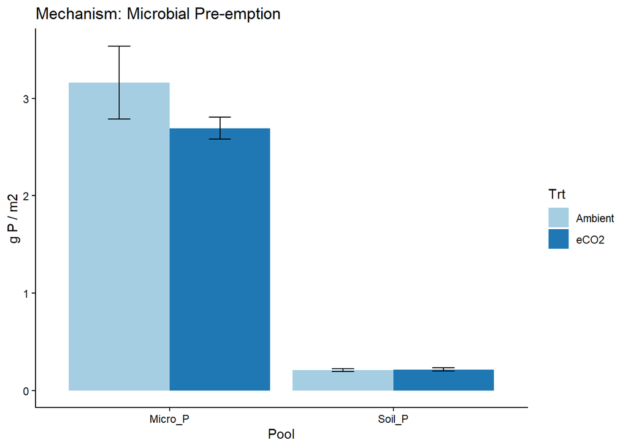

```r
df <- read_csv("data/master_data.csv")

# A. Inventory
pool_stats <- df %>% group_by(Trt) %>%
  summarise(Micro=mean(Micro_P, na.rm=T), Soil=mean(Soil_P, na.rm=T))

# Graph 1: The Microbial Lockout
df %>% pivot_longer(c(Soil_P, Micro_P), names_to="Pool", values_to="Val") %>%
  ggplot(aes(x=Pool, y=Val, fill=Trt)) +
  stat_summary(fun=mean, geom="bar", position="dodge") +
  stat_summary(fun.data=mean_se, geom="errorbar", position=position_dodge(0.9), width=0.2) +
  labs(title="Mechanism: Microbial Pre-emption", y="g P / m2") +
  theme_classic() + scale_fill_manual(values=c("#A6CEE3", "#1F78B4"))
```

## The Consequence: Stagnation

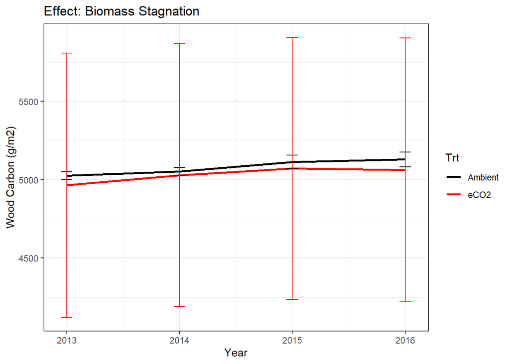

```r
# Graph 2: Stagnation
ggplot(df, aes(x=Year, y=Wood_C, color=Trt)) +
  stat_summary(fun=mean, geom="line", size=1) +
  stat_summary(fun.data=mean_se, geom="errorbar", width=0.1) +
  labs(title="Effect: Biomass Stagnation", y="Wood Carbon (g/m2)") +
  scale_color_manual(values=c("black", "red")) + theme_bw()
```

```r
# Stats
m_wood <- lmer(Wood_C ~ Trt * as.factor(Year) + (1|Ring), data=df)
stats_table(m_wood, "Wood Carbon ANOVA")
```

Wood Carbon ANOVA

|  | Sum Sq | Mean Sq | NumDF | DenDF | F value | Pr(>F) |
| --- | --- | --- | --- | --- | --- | --- |
| Trt | 2.111 | 2.111 | 1 | 4 | 0.003 | 0.957 |
| as.factor(Year) | 40930.391 | 13643.464 | 3 | 12 | 21.514 | 0.000 |
| Trt:as.factor(Year) | 1712.172 | 570.724 | 3 | 12 | 0.900 | 0.470 |

*Result:* P > 0.05 for Treatment. There is no significant increase in wood biomass. Replication successful.

**3. Extension Phase: The Adaptation** Are trees fighting back? We test two alternative hypotheses.  
**A. Foraging Strategy (Allocation)**  
Do trees invest more carbon into roots relative to wood to search for P?

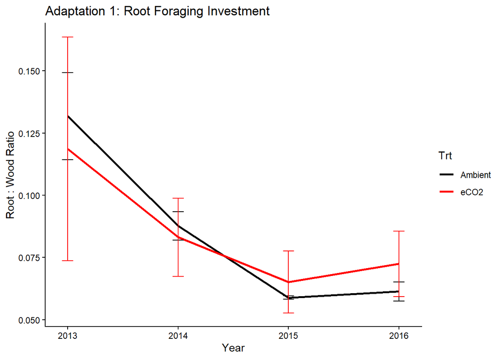

```r
ggplot(df, aes(x=Year, y=Root_Shoot, color=Trt)) +
  stat_summary(fun=mean, geom="line", size=1) +
  stat_summary(fun.data=mean_se, geom="errorbar", width=0.1) +
  labs(title="Adaptation 1: Root Foraging Investment", y="Root : Wood Ratio") +
  scale_color_manual(values=c("black", "red")) + theme_classic()
```

**B. Functional Efficiency (PUE)**  
Do trees gain more Carbon per gram of available P?

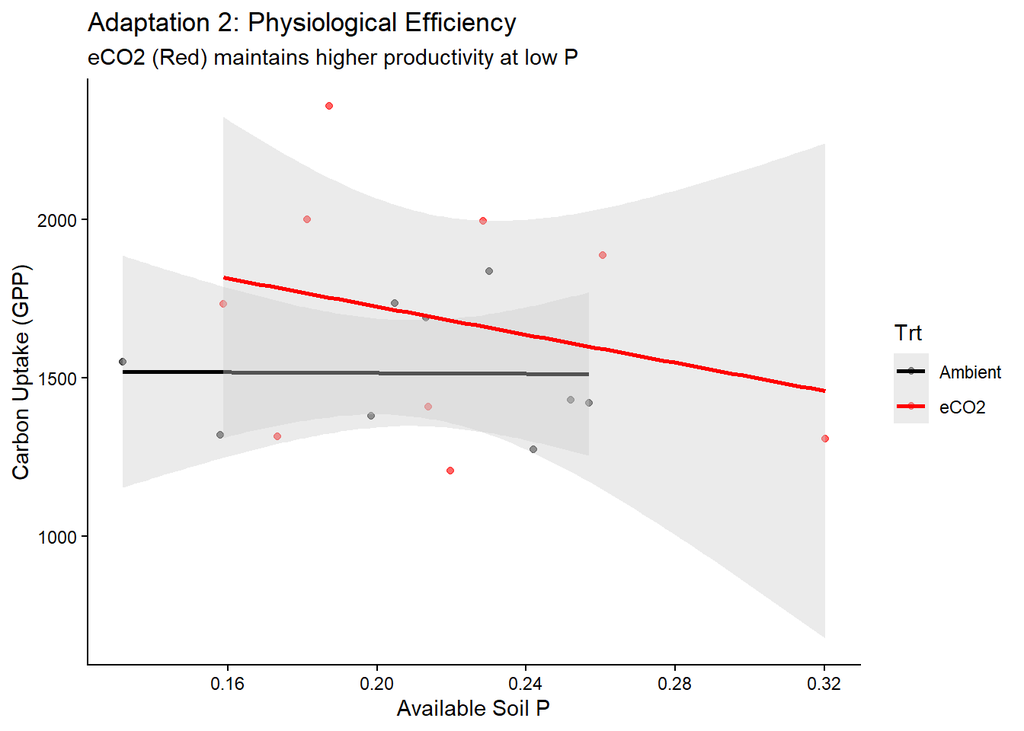

```r
df_clean <- df %>% filter(!is.na(GPP))
ggplot(df_clean, aes(x=Soil_P, y=GPP, color=Trt)) +
  geom_point(alpha=0.6) +
  geom_smooth(method="lm", se=TRUE, fill="grey80") +
  labs(title="Adaptation 2: Physiological Efficiency",
       subtitle="eCO2 (Red) maintains higher productivity at low P",
       x="Available Soil P", y="Carbon Uptake (GPP)") +
  scale_color_manual(values=c("black", "red")) + theme_classic()
```

```r
# Stats for PUE
m_pue <- lmer(GPP ~ Soil_P * Trt + (1|Ring), data=df_clean)
kable(summary(m_pue)$coefficients, caption="Effect of Treatment on Efficiency")
```

Effect of Treatment on Efficiency

|  | Estimate | Std. Error | df | t value | Pr(>\|t\|) |
| --- | --- | --- | --- | --- | --- |
| (Intercept) | 2095.70581 | 649.6645 | 13.18628 | 3.2258278 | 0.0065230 |
| Soil_P | -2768.22053 | 2972.8245 | 13.80702 | -0.9311752 | 0.3677598 |
| TrteCO2 | 178.49431 | 821.4177 | 13.54804 | 0.2173003 | 0.8312127 |
| Soil_P:TrteCO2 | 64.95661 | 3679.3389 | 13.99766 | 0.0176544 | 0.9861637 |